# Motherly Plus: Results Report

Single-session psychotherapy supported by the Motherly app for postpartum depression

Daniel Fatori

# 1 Overview of analysis plan

- **Groups:** Waitlist (Control) vs. Intervention (Motherly Plus).
- **Timepoints:** T1 (baseline), T2 (week 2), T3 (week 4, post-treatment), T4 (week 8, follow-up).
- **Primary outcome:**
  - Quick Inventory of Depressive Symptomatology, Clinician-Rated (QIDS-C16) total score at T3
- **Secondary outcomes (T3 and T4, unless noted):**
  - Quick Inventory of Depressive Symptomatology, Self-Report (QIDS-SR16)
  - Generalized Anxiety Disorder-7 (GAD-7)
  - Pittsburgh Sleep Quality Index (PSQI)
  - Parenting Stress Index – Short Form (PSI-SF): parental distress, parent-child dysfunctional interaction and total stress
  - Sheehan Disability Scale (SDS)
  - Edinburgh Postnatal Depression Scale (EPDS)
  - Clinical Global Impression – Improvement (CGI-I), T3 only
- **Analysis:**
  - Intention-to-treat: all randomized participants.
  - Missing data: described before the analyses (availability of each outcome by group). Missing values were then handled by multiple imputation by chained equations (MICE, 100 imputations), with results pooled by Rubin’s rules.
  - Model: generalized estimating equations (GEE) with AR1 working correlation and robust standard errors, fitted as `outcome ~ time + time × group` (no group main effect; Twisk et al., 2018, equation 2d). Baseline (T1) is the intercept and is assumed equal in both groups by randomization, so the effect of the intervention at each follow-up is the `Group × Time` coefficient.
  - CGI-I (T3 only, no baseline) was analyzed as a continuous score (1–7) with a linear regression on group.
  - Two-sided α = 0.05; 95% confidence intervals; Cohen’s d = group contrast divided by the pooled within-group standard deviation at that timepoint.
  - A complete-case analysis (no imputation) of every outcome is reported separately.

In all contrasts the comparison is **Waitlist − Intervention**, so a **positive estimate (and positive d) favors the intervention** (higher symptom score in the waitlist group). The `Group × Time` coefficients in the model tables have the opposite sign (Intervention − Waitlist), so a negative coefficient also favors the intervention. FMI is the fraction of missing information of each pooled parameter.

# 2 Participants and baseline characteristics

**Table 1. Baseline characteristics by randomized group**

| **Characteristic** | **Overall** N = 104<sup>1</sup> | **Waitlist** N = 52<sup>1</sup> | **Intervention** N = 52<sup>1</sup> |
| --- | --- | --- | --- |
| Age (years) | 28.49 (4.56) | 28.52 (4.70) | 28.46 (4.47) |
| Infant age (months) | 4.40 (2.57) | 4.01 (2.30) | 4.79 (2.78) |
| White race/skin color | 50 (48%) | 26 (50%) | 24 (46%) |
| College degree or higher | 59 (57%) | 31 (60%) | 28 (54%) |
| Married or in stable relationship | 66 (63%) | 27 (52%) | 39 (75%) |
| Working for pay | 42 (40%) | 16 (31%) | 26 (50%) |
| Currently studying | 18 (17%) | 13 (25%) | 5 (9.6%) |
| Family income (BRL thousands) | 3.16 (1.26) | 3.04 (1.40) | 3.29 (1.11) |
| People in household | 3.74 (1.15) | 3.85 (1.00) | 3.63 (1.28) |
| Number of children | 1.89 (0.96) | 1.77 (0.96) | 2.02 (0.96) |
| Firstborn child | 44 (42%) | 26 (50%) | 18 (35%) |
| Prenatal visits | 7.83 (2.77) | 8.08 (2.88) | 7.58 (2.66) |
| High-risk pregnancy | 17 (16%) | 10 (19%) | 7 (13%) |
| Receiving mental health treatment | 31 (30%) | 19 (37%) | 12 (23%) |
| QIDS-C16 total score | 16.87 (4.44) | 17.25 (4.89) | 16.48 (3.94) |
| QIDS-SR16 total score | 17.34 (5.21) | 18.19 (5.41) | 16.48 (4.91) |
| GAD-7 total score | 10.95 (4.89) | 11.15 (5.10) | 10.75 (4.71) |
| SDS total score | 15.26 (6.50) | 15.54 (6.74) | 14.98 (6.30) |
| EPDS total score | 15.69 (5.24) | 16.35 (5.39) | 15.04 (5.05) |
| PSQI total score | 10.16 (2.24) | 10.17 (2.44) | 10.15 (2.05) |
| PSI-SF total score | 98.48 (18.55) | 99.83 (19.62) | 97.13 (17.51) |
| PSI-SF parental distress | 31.97 (8.15) | 32.13 (8.65) | 31.81 (7.71) |
| PSI-SF dysfunctional interaction | 32.86 (7.11) | 32.69 (7.71) | 33.02 (6.54) |
| PSI-SF difficult child | 33.65 (6.27) | 35.00 (6.31) | 32.31 (5.99) |
| CGI-Severity score | 4.48 (0.88) | 4.31 (0.85) | 4.65 (0.88) |

<sup>1</sup> Mean (SD); n (%)

# 3 Missing data

Description of the observed data, before imputation. A value is missing when a randomized participant has no value at a timepoint where the instrument is scheduled.

**Table 2. Availability of outcome data by group.** Values are n (%) of randomized participants with the outcome observed.

| **Outcome observed** | **Overall** N = 104<sup>1</sup> | **Waitlist** N = 52<sup>1</sup> | **Intervention** N = 52<sup>1</sup> |
| --- | --- | --- | --- |
| QIDS-C16 (primary), T3 | 76 (73%) | 36 (69%) | 40 (77%) |
| QIDS-SR16, T3 | 76 (73%) | 36 (69%) | 40 (77%) |
| QIDS-SR16, T4 | 81 (78%) | 42 (81%) | 39 (75%) |
| GAD-7, T3 | 76 (73%) | 36 (69%) | 40 (77%) |
| GAD-7, T4 | 81 (78%) | 42 (81%) | 39 (75%) |
| PSQI, T3 | 76 (73%) | 36 (69%) | 40 (77%) |
| PSQI, T4 | 81 (78%) | 42 (81%) | 39 (75%) |
| PSI-SF parental distress, T3 | 76 (73%) | 36 (69%) | 40 (77%) |
| PSI-SF parental distress, T4 | 81 (78%) | 42 (81%) | 39 (75%) |
| PSI-SF parent-child dysfunctional interaction, T3 | 76 (73%) | 36 (69%) | 40 (77%) |
| PSI-SF parent-child dysfunctional interaction, T4 | 81 (78%) | 42 (81%) | 39 (75%) |
| PSI-SF total stress, T3 | 76 (73%) | 36 (69%) | 40 (77%) |
| PSI-SF total stress, T4 | 81 (78%) | 42 (81%) | 39 (75%) |
| SDS, T3 | 76 (73%) | 36 (69%) | 40 (77%) |
| SDS, T4 | 81 (78%) | 42 (81%) | 39 (75%) |
| EPDS, T3 | 76 (73%) | 36 (69%) | 40 (77%) |
| EPDS, T4 | 81 (78%) | 42 (81%) | 39 (75%) |
| CGI-I, T3 | 76 (73%) | 36 (69%) | 40 (77%) |

<sup>1</sup> n (%)

# 4 Primary outcome: Quick Inventory of Depressive Symptomatology, Clinician-Rated (QIDS-C16), at T3

GEE model coefficients (pooled over the imputed datasets). The `Group × Time` term is the effect of the intervention at that timepoint (Intervention − Waitlist): a negative coefficient indicates greater symptom reduction in the intervention group. Significant *p*-values (< 0.05) are shown in **bold**.

Table 3a. QIDS-C16 GEE model coefficients (pooled).

| Term | Estimate | SE | 95% CI | p | FMI |
| --- | --- | --- | --- | --- | --- |
| Intercept (baseline, both groups) | 16.865 | 0.433 | 16.012, 17.719 | **<0.001** | 0.01 |
| Time T3 (change from T1, Waitlist) | -1.641 | 0.358 | -2.349, -0.932 | **<0.001** | 0.28 |
| Group × Time T3 (Intervention vs. Waitlist) | -6.157 | 0.481 | -7.108, -5.207 | **<0.001** | 0.27 |

Table 3b. QIDS-C16 estimated marginal means. Baseline (T1) is the same in both groups by model construction.

| Group | Timepoint | Mean | SE | 95% CI |
| --- | --- | --- | --- | --- |
| Waitlist | T1 | 16.87 | 0.43 | 16.02, 17.71 |
| Intervention | T1 | 16.87 | 0.43 | 16.02, 17.71 |
| Waitlist | T3 | 15.22 | 0.47 | 14.30, 16.15 |
| Intervention | T3 | 9.07 | 0.43 | 8.21, 9.92 |

Table 3c. QIDS-C16 group contrast at T3.

| Contrast | Timepoint | Estimate | SE | 95% CI | Cohen’s d (95% CI) | p |
| --- | --- | --- | --- | --- | --- | --- |
| Waitlist - Intervention | T3 | 6.16 | 0.48 | 5.21, 7.11 | 1.64 (1.30, 1.99) | **<0.001** |

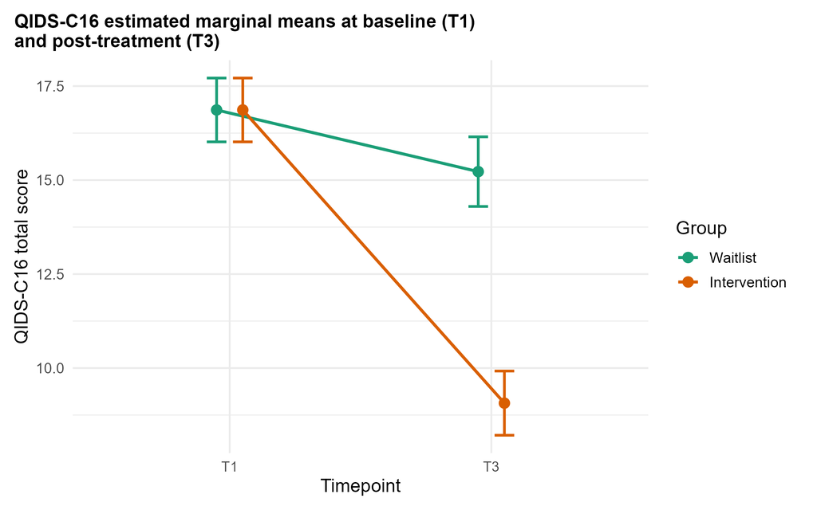

Figure 1. QIDS-C16 estimated marginal means at baseline (T1) and post-treatment (T3), by group.

# 5 Secondary outcomes

## 5.1 Quick Inventory of Depressive Symptomatology, Self-Report (QIDS-SR16)

Table 4a. QIDS-SR16 GEE model coefficients (pooled).

| Term | Estimate | SE | 95% CI | p | FMI |
| --- | --- | --- | --- | --- | --- |
| Intercept (baseline, both groups) | 17.337 | 0.509 | 16.336, 18.337 | **<0.001** | 0.01 |
| Time T3 (change from T1, Waitlist) | -1.849 | 0.512 | -2.859, -0.838 | **<0.001** | 0.31 |
| Time T4 (change from T1, Waitlist) | -4.780 | 0.407 | -5.581, -3.979 | **<0.001** | 0.17 |
| Group × Time T3 (Intervention vs. Waitlist) | -6.779 | 0.652 | -8.063, -5.494 | **<0.001** | 0.24 |
| Group × Time T4 (Intervention vs. Waitlist) | -6.758 | 0.534 | -7.811, -5.706 | **<0.001** | 0.26 |

Table 4b. QIDS-SR16 estimated marginal means. Baseline (T1) is the same in both groups by model construction.

| Group | Timepoint | Mean | SE | 95% CI |
| --- | --- | --- | --- | --- |
| Waitlist | T1 | 17.34 | 0.51 | 16.34, 18.34 |
| Intervention | T1 | 17.34 | 0.51 | 16.34, 18.34 |
| Waitlist | T3 | 15.49 | 0.63 | 14.25, 16.72 |
| Intervention | T3 | 8.71 | 0.47 | 7.78, 9.64 |
| Waitlist | T4 | 12.56 | 0.50 | 11.56, 13.55 |
| Intervention | T4 | 5.80 | 0.43 | 4.95, 6.64 |

Table 4c. QIDS-SR16 group contrasts by timepoint.

| Contrast | Timepoint | Estimate | SE | 95% CI | Cohen’s d (95% CI) | p |
| --- | --- | --- | --- | --- | --- | --- |
| Waitlist - Intervention | T3 | 6.78 | 0.65 | 5.49, 8.06 | 1.60 (1.22, 1.97) | **<0.001** |
| Waitlist - Intervention | T4 | 6.76 | 0.53 | 5.71, 7.81 | 1.81 (1.43, 2.19) | **<0.001** |

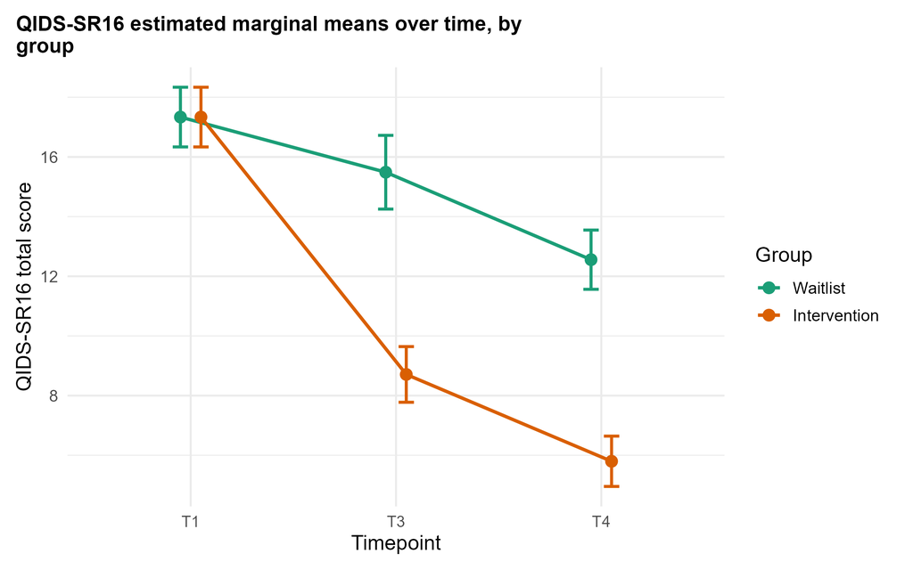

Figure 2. QIDS-SR16 estimated marginal means over time, by group.

## 5.2 Generalized Anxiety Disorder-7 (GAD-7)

Table 5a. GAD-7 GEE model coefficients (pooled).

| Term | Estimate | SE | 95% CI | p | FMI |
| --- | --- | --- | --- | --- | --- |
| Intercept (baseline, both groups) | 10.952 | 0.477 | 10.013, 11.891 | **<0.001** | 0.01 |
| Time T3 (change from T1, Waitlist) | -1.405 | 0.361 | -2.116, -0.695 | **<0.001** | 0.24 |
| Time T4 (change from T1, Waitlist) | -3.562 | 0.319 | -4.190, -2.933 | **<0.001** | 0.16 |
| Group × Time T3 (Intervention vs. Waitlist) | -3.219 | 0.510 | -4.224, -2.214 | **<0.001** | 0.21 |
| Group × Time T4 (Intervention vs. Waitlist) | -2.494 | 0.502 | -3.484, -1.504 | **<0.001** | 0.25 |

Table 5b. GAD-7 estimated marginal means. Baseline (T1) is the same in both groups by model construction.

| Group | Timepoint | Mean | SE | 95% CI |
| --- | --- | --- | --- | --- |
| Waitlist | T1 | 10.95 | 0.48 | 10.01, 11.89 |
| Intervention | T1 | 10.95 | 0.48 | 10.01, 11.89 |
| Waitlist | T3 | 9.55 | 0.52 | 8.53, 10.57 |
| Intervention | T3 | 6.33 | 0.45 | 5.44, 7.22 |
| Waitlist | T4 | 7.39 | 0.43 | 6.54, 8.24 |
| Intervention | T4 | 4.90 | 0.44 | 4.04, 5.76 |

Table 5c. GAD-7 group contrasts by timepoint.

| Contrast | Timepoint | Estimate | SE | 95% CI | Cohen’s d (95% CI) | p |
| --- | --- | --- | --- | --- | --- | --- |
| Waitlist - Intervention | T3 | 3.22 | 0.51 | 2.21, 4.22 | 0.79 (0.52, 1.07) | **<0.001** |
| Waitlist - Intervention | T4 | 2.49 | 0.50 | 1.50, 3.48 | 0.72 (0.42, 1.02) | **<0.001** |

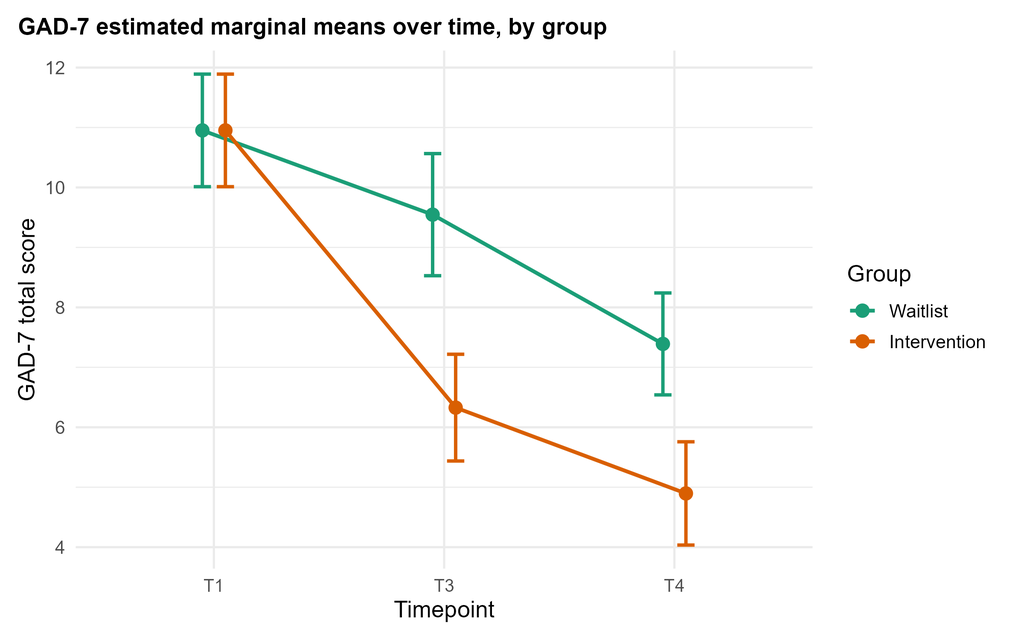

Figure 3. GAD-7 estimated marginal means over time, by group.

## 5.3 Pittsburgh Sleep Quality Index (PSQI)

Table 6a. PSQI GEE model coefficients (pooled).

| Term | Estimate | SE | 95% CI | p | FMI |
| --- | --- | --- | --- | --- | --- |
| Intercept (baseline, both groups) | 10.163 | 0.219 | 9.733, 10.594 | **<0.001** | 0.01 |
| Time T3 (change from T1, Waitlist) | -0.512 | 0.263 | -1.032, 0.009 | 0.054 | 0.38 |
| Time T4 (change from T1, Waitlist) | -2.137 | 0.184 | -2.500, -1.774 | **<0.001** | 0.26 |
| Group × Time T3 (Intervention vs. Waitlist) | -2.012 | 0.345 | -2.693, -1.331 | **<0.001** | 0.38 |
| Group × Time T4 (Intervention vs. Waitlist) | -1.419 | 0.298 | -2.007, -0.831 | **<0.001** | 0.27 |

Table 6b. PSQI estimated marginal means. Baseline (T1) is the same in both groups by model construction.

| Group | Timepoint | Mean | SE | 95% CI |
| --- | --- | --- | --- | --- |
| Waitlist | T1 | 10.16 | 0.22 | 9.73, 10.59 |
| Intervention | T1 | 10.16 | 0.22 | 9.73, 10.59 |
| Waitlist | T3 | 9.65 | 0.33 | 9.01, 10.30 |
| Intervention | T3 | 7.64 | 0.27 | 7.11, 8.17 |
| Waitlist | T4 | 8.03 | 0.25 | 7.53, 8.52 |
| Intervention | T4 | 6.61 | 0.26 | 6.10, 7.11 |

Table 6c. PSQI group contrasts by timepoint.

| Contrast | Timepoint | Estimate | SE | 95% CI | Cohen’s d (95% CI) | p |
| --- | --- | --- | --- | --- | --- | --- |
| Waitlist - Intervention | T3 | 2.01 | 0.34 | 1.33, 2.69 | 0.87 (0.55, 1.18) | **<0.001** |
| Waitlist - Intervention | T4 | 1.42 | 0.30 | 0.83, 2.01 | 0.71 (0.40, 1.02) | **<0.001** |

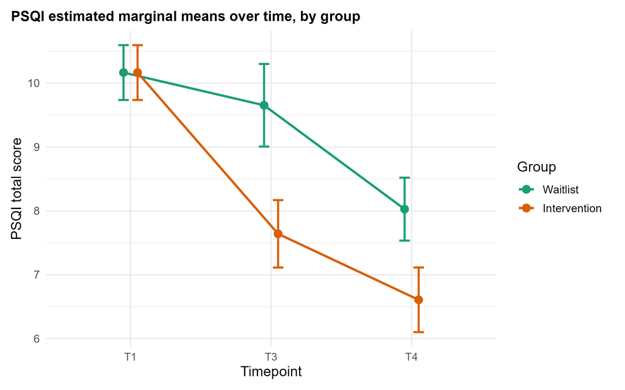

Figure 4. PSQI estimated marginal means over time, by group.

## 5.4 Parenting Stress Index – Short Form (PSI-SF): parental distress

Table 7a. PSI-SF parental distress GEE model coefficients (pooled).

| Term | Estimate | SE | 95% CI | p | FMI |
| --- | --- | --- | --- | --- | --- |
| Intercept (baseline, both groups) | 31.971 | 0.796 | 30.405, 33.537 | **<0.001** | 0.01 |
| Time T3 (change from T1, Waitlist) | -4.300 | 1.012 | -6.295, -2.304 | **<0.001** | 0.24 |
| Time T4 (change from T1, Waitlist) | -7.126 | 0.751 | -8.606, -5.647 | **<0.001** | 0.15 |
| Group × Time T3 (Intervention vs. Waitlist) | -6.856 | 1.302 | -9.423, -4.289 | **<0.001** | 0.24 |
| Group × Time T4 (Intervention vs. Waitlist) | -6.288 | 1.036 | -8.330, -4.246 | **<0.001** | 0.21 |

Table 7b. PSI-SF parental distress estimated marginal means. Baseline (T1) is the same in both groups by model construction.

| Group | Timepoint | Mean | SE | 95% CI |
| --- | --- | --- | --- | --- |
| Waitlist | T1 | 31.97 | 0.80 | 30.41, 33.53 |
| Intervention | T1 | 31.97 | 0.80 | 30.41, 33.53 |
| Waitlist | T3 | 27.67 | 1.03 | 25.64, 29.70 |
| Intervention | T3 | 20.82 | 0.96 | 18.93, 22.70 |
| Waitlist | T4 | 24.84 | 0.87 | 23.14, 26.55 |
| Intervention | T4 | 18.56 | 0.83 | 16.93, 20.19 |

Table 7c. PSI-SF parental distress group contrasts by timepoint.

| Contrast | Timepoint | Estimate | SE | 95% CI | Cohen’s d (95% CI) | p |
| --- | --- | --- | --- | --- | --- | --- |
| Waitlist - Intervention | T3 | 6.86 | 1.30 | 4.29, 9.42 | 0.99 (0.60, 1.39) | **<0.001** |
| Waitlist - Intervention | T4 | 6.29 | 1.04 | 4.25, 8.33 | 0.96 (0.62, 1.30) | **<0.001** |

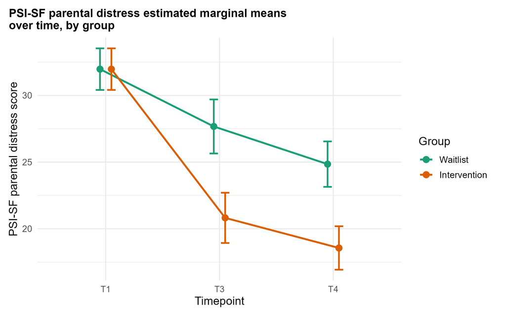

Figure 5. PSI-SF parental distress estimated marginal means over time, by group.

## 5.5 Parenting Stress Index – Short Form (PSI-SF): parent-child dysfunctional interaction

Table 8a. PSI-SF parent-child dysfunctional interaction GEE model coefficients (pooled).

| Term | Estimate | SE | 95% CI | p | FMI |
| --- | --- | --- | --- | --- | --- |
| Intercept (baseline, both groups) | 32.856 | 0.694 | 31.490, 34.222 | **<0.001** | 0.01 |
| Time T3 (change from T1, Waitlist) | -4.435 | 1.118 | -6.639, -2.231 | **<0.001** | 0.22 |
| Time T4 (change from T1, Waitlist) | -7.942 | 0.823 | -9.562, -6.322 | **<0.001** | 0.12 |
| Group × Time T3 (Intervention vs. Waitlist) | -3.270 | 1.333 | -5.897, -0.642 | **0.015** | 0.24 |
| Group × Time T4 (Intervention vs. Waitlist) | -4.121 | 0.978 | -6.048, -2.194 | **<0.001** | 0.15 |

Table 8b. PSI-SF parent-child dysfunctional interaction estimated marginal means. Baseline (T1) is the same in both groups by model construction.

| Group | Timepoint | Mean | SE | 95% CI |
| --- | --- | --- | --- | --- |
| Waitlist | T1 | 32.86 | 0.69 | 31.50, 34.22 |
| Intervention | T1 | 32.86 | 0.69 | 31.50, 34.22 |
| Waitlist | T3 | 28.42 | 1.03 | 26.38, 30.46 |
| Intervention | T3 | 25.15 | 0.98 | 23.21, 27.09 |
| Waitlist | T4 | 24.91 | 0.81 | 23.33, 26.50 |
| Intervention | T4 | 20.79 | 0.69 | 19.43, 22.16 |

Table 8c. PSI-SF parent-child dysfunctional interaction group contrasts by timepoint.

| Contrast | Timepoint | Estimate | SE | 95% CI | Cohen’s d (95% CI) | p |
| --- | --- | --- | --- | --- | --- | --- |
| Waitlist - Intervention | T3 | 3.27 | 1.33 | 0.64, 5.90 | 0.49 (0.09, 0.90) | **0.015** |
| Waitlist - Intervention | T4 | 4.12 | 0.98 | 2.19, 6.05 | 0.75 (0.38, 1.11) | **<0.001** |

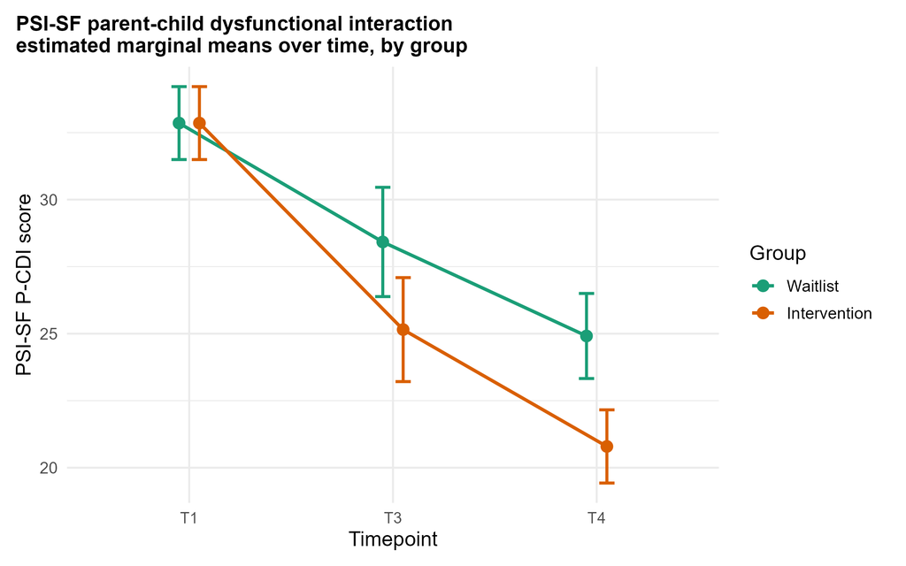

Figure 6. PSI-SF parent-child dysfunctional interaction estimated marginal means over time, by group.

## 5.6 Parenting Stress Index – Short Form (PSI-SF): total stress

Table 9a. PSI-SF total stress GEE model coefficients (pooled).

| Term | Estimate | SE | 95% CI | p | FMI |
| --- | --- | --- | --- | --- | --- |
| Intercept (baseline, both groups) | 98.481 | 1.810 | 94.919, 102.043 | **<0.001** | 0.01 |
| Time T3 (change from T1, Waitlist) | -13.733 | 2.149 | -17.971, -9.494 | **<0.001** | 0.29 |
| Time T4 (change from T1, Waitlist) | -21.476 | 1.560 | -24.550, -18.403 | **<0.001** | 0.20 |
| Group × Time T3 (Intervention vs. Waitlist) | -11.856 | 2.709 | -17.199, -6.512 | **<0.001** | 0.28 |
| Group × Time T4 (Intervention vs. Waitlist) | -11.574 | 2.065 | -15.643, -7.506 | **<0.001** | 0.19 |

Table 9b. PSI-SF total stress estimated marginal means. Baseline (T1) is the same in both groups by model construction.

| Group | Timepoint | Mean | SE | 95% CI |
| --- | --- | --- | --- | --- |
| Waitlist | T1 | 98.48 | 1.81 | 94.93, 102.03 |
| Intervention | T1 | 98.48 | 1.81 | 94.93, 102.03 |
| Waitlist | T3 | 84.75 | 2.34 | 80.14, 89.36 |
| Intervention | T3 | 72.89 | 2.13 | 68.69, 77.09 |
| Waitlist | T4 | 77.00 | 1.95 | 73.17, 80.84 |
| Intervention | T4 | 65.43 | 1.84 | 61.81, 69.05 |

Table 9c. PSI-SF total stress group contrasts by timepoint.

| Contrast | Timepoint | Estimate | SE | 95% CI | Cohen’s d (95% CI) | p |
| --- | --- | --- | --- | --- | --- | --- |
| Waitlist - Intervention | T3 | 11.86 | 2.71 | 6.51, 17.20 | 0.72 (0.38, 1.06) | **<0.001** |
| Waitlist - Intervention | T4 | 11.57 | 2.07 | 7.51, 15.64 | 0.75 (0.47, 1.04) | **<0.001** |

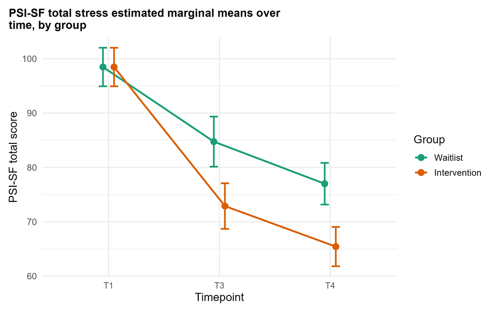

Figure 7. PSI-SF total stress estimated marginal means over time, by group.

## 5.7 Sheehan Disability Scale (SDS)

Table 10a. SDS GEE model coefficients (pooled).

| Term | Estimate | SE | 95% CI | p | FMI |
| --- | --- | --- | --- | --- | --- |
| Intercept (baseline, both groups) | 15.260 | 0.634 | 14.012, 16.508 | **<0.001** | 0.01 |
| Time T3 (change from T1, Waitlist) | -2.478 | 0.481 | -3.427, -1.529 | **<0.001** | 0.25 |
| Time T4 (change from T1, Waitlist) | -4.051 | 0.460 | -4.956, -3.146 | **<0.001** | 0.14 |
| Group × Time T3 (Intervention vs. Waitlist) | -3.014 | 0.654 | -4.303, -1.725 | **<0.001** | 0.25 |
| Group × Time T4 (Intervention vs. Waitlist) | -3.201 | 0.680 | -4.540, -1.862 | **<0.001** | 0.14 |

Table 10b. SDS estimated marginal means. Baseline (T1) is the same in both groups by model construction.

| Group | Timepoint | Mean | SE | 95% CI |
| --- | --- | --- | --- | --- |
| Waitlist | T1 | 15.26 | 0.63 | 14.01, 16.51 |
| Intervention | T1 | 15.26 | 0.63 | 14.01, 16.51 |
| Waitlist | T3 | 12.78 | 0.66 | 11.48, 14.09 |
| Intervention | T3 | 9.77 | 0.63 | 8.52, 11.02 |
| Waitlist | T4 | 11.21 | 0.61 | 10.01, 12.41 |
| Intervention | T4 | 8.01 | 0.60 | 6.83, 9.18 |

Table 10c. SDS group contrasts by timepoint.

| Contrast | Timepoint | Estimate | SE | 95% CI | Cohen’s d (95% CI) | p |
| --- | --- | --- | --- | --- | --- | --- |
| Waitlist - Intervention | T3 | 3.01 | 0.65 | 1.72, 4.30 | 0.55 (0.30, 0.79) | **<0.001** |
| Waitlist - Intervention | T4 | 3.20 | 0.68 | 1.86, 4.54 | 0.65 (0.36, 0.93) | **<0.001** |

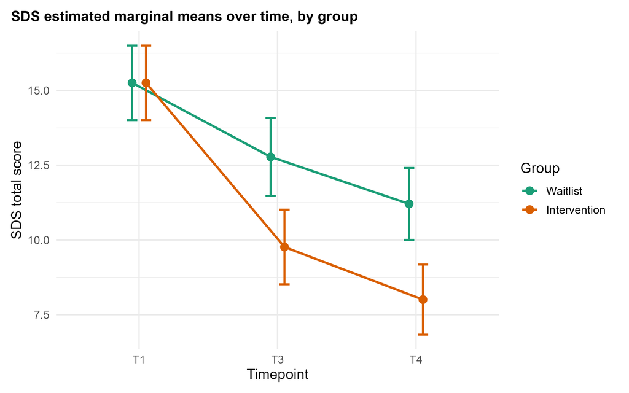

Figure 8. SDS estimated marginal means over time, by group.

## 5.8 Edinburgh Postnatal Depression Scale (EPDS)

Table 11a. EPDS GEE model coefficients (pooled).

| Term | Estimate | SE | 95% CI | p | FMI |
| --- | --- | --- | --- | --- | --- |
| Intercept (baseline, both groups) | 15.692 | 0.511 | 14.686, 16.698 | **<0.001** | 0.01 |
| Time T3 (change from T1, Waitlist) | -0.544 | 0.508 | -1.546, 0.458 | 0.285 | 0.24 |
| Time T4 (change from T1, Waitlist) | -4.496 | 0.459 | -5.400, -3.592 | **<0.001** | 0.16 |
| Group × Time T3 (Intervention vs. Waitlist) | -5.905 | 0.633 | -7.152, -4.658 | **<0.001** | 0.20 |
| Group × Time T4 (Intervention vs. Waitlist) | -4.211 | 0.612 | -5.418, -3.005 | **<0.001** | 0.18 |

Table 11b. EPDS estimated marginal means. Baseline (T1) is the same in both groups by model construction.

| Group | Timepoint | Mean | SE | 95% CI |
| --- | --- | --- | --- | --- |
| Waitlist | T1 | 15.69 | 0.51 | 14.69, 16.70 |
| Intervention | T1 | 15.69 | 0.51 | 14.69, 16.70 |
| Waitlist | T3 | 15.15 | 0.62 | 13.93, 16.37 |
| Intervention | T3 | 9.24 | 0.53 | 8.20, 10.29 |
| Waitlist | T4 | 11.20 | 0.55 | 10.11, 12.28 |
| Intervention | T4 | 6.99 | 0.51 | 5.98, 7.99 |

Table 11c. EPDS group contrasts by timepoint.

| Contrast | Timepoint | Estimate | SE | 95% CI | Cohen’s d (95% CI) | p |
| --- | --- | --- | --- | --- | --- | --- |
| Waitlist - Intervention | T3 | 5.90 | 0.63 | 4.66, 7.15 | 1.27 (0.95, 1.59) | **<0.001** |
| Waitlist - Intervention | T4 | 4.21 | 0.61 | 3.00, 5.42 | 0.98 (0.67, 1.29) | **<0.001** |

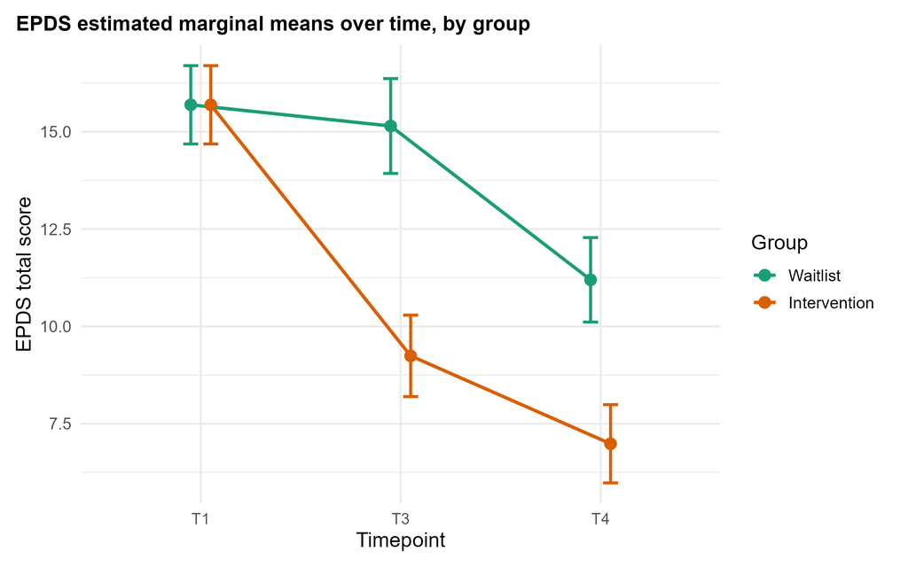

Figure 9. EPDS estimated marginal means over time, by group.

## 5.9 Clinical Global Impression – Improvement (CGI-I) at T3

Clinical Global Impression – Improvement is measured at T3 and has no baseline value. It is scored from 1 (very much improved) to 7 (very much worse) and analyzed as a continuous outcome, with a linear regression on group in each imputed dataset (pooled). The contrast is Waitlist − Intervention, so a positive estimate favors the intervention (lower score = more improvement).

Table 12a. CGI-I estimated marginal means at T3.

| Group | Timepoint | Mean | SE | 95% CI |
| --- | --- | --- | --- | --- |
| Waitlist | T3 | 2.98 | 0.27 | 2.45, 3.52 |
| Intervention | T3 | 3.38 | 0.26 | 2.87, 3.89 |

Table 12b. CGI-I group contrast at T3.

| Contrast | Timepoint | Estimate | SE | 95% CI | Cohen’s d (95% CI) | p |
| --- | --- | --- | --- | --- | --- | --- |
| Waitlist - Intervention | T3 | -0.4 | 0.37 | -1.13, 0.34 | -0.23 (-0.67, 0.20) | 0.286 |

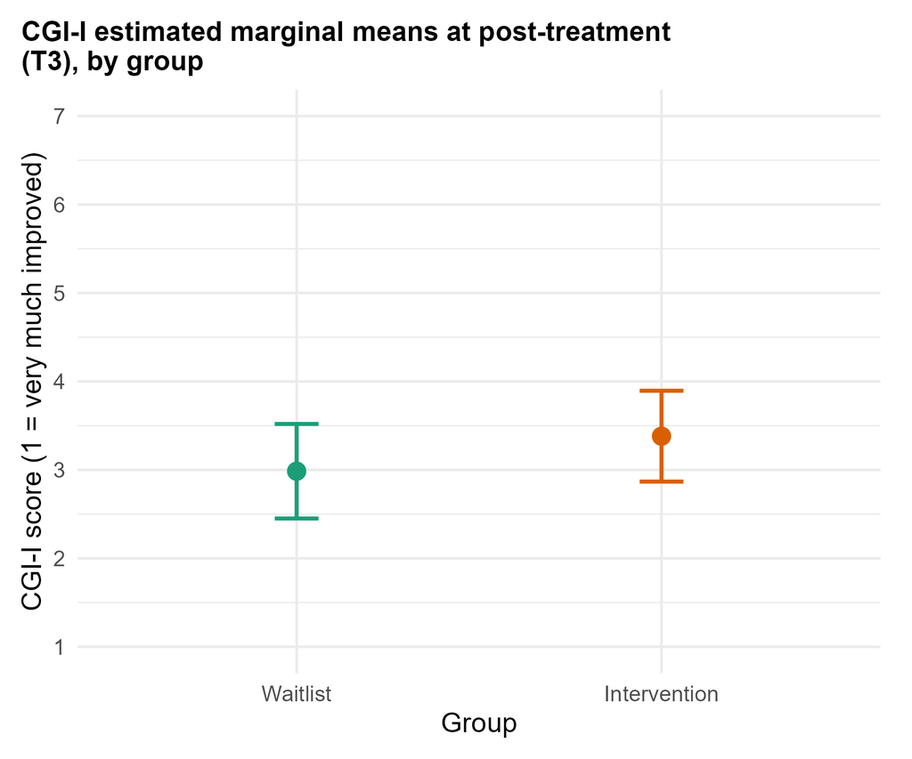

Figure 10. CGI-I estimated marginal means at post-treatment (T3), by group. Scores range from 1 (very much improved) to 7 (very much worse).

# 6 Complete-case analysis

Analysis without imputation. For each outcome, only participants observed at **every** timepoint of that outcome are included (participants with any missing value are excluded before fitting, so they do not contribute even their baseline). The models are the same as in the intention-to-treat analyses and are fitted once on the observed data (CGI-I: linear regression on group). *n* is the number analyzed in the Waitlist (W) and Intervention (I) groups, and *Excluded* is the number of randomized participants left out.

Table 13. Complete-case group contrasts (Waitlist − Intervention) by timepoint.

| Outcome | Timepoint | n (W / I) | Excluded | Estimate | SE | 95% CI | Cohen’s d (95% CI) | p |
| --- | --- | --- | --- | --- | --- | --- | --- | --- |
| QIDS-C16 (primary) | T3 | 36 / 40 | 28 | 6.04 | 0.46 | 5.13, 6.94 | 1.61 (1.25, 1.96) | **<0.001** |
| QIDS-SR16 | T3 | 30 / 31 | 43 | 6.85 | 0.69 | 5.49, 8.21 | 1.72 (1.26, 2.19) | **<0.001** |
| QIDS-SR16 | T4 | 30 / 31 | 43 | 6.62 | 0.60 | 5.43, 7.80 | 1.79 (1.33, 2.24) | **<0.001** |
| GAD-7 | T3 | 30 / 31 | 43 | 3.02 | 0.60 | 1.84, 4.20 | 0.80 (0.46, 1.15) | **<0.001** |
| GAD-7 | T4 | 30 / 31 | 43 | 2.54 | 0.60 | 1.36, 3.73 | 0.80 (0.40, 1.21) | **<0.001** |
| PSQI | T3 | 30 / 31 | 43 | 1.83 | 0.35 | 1.15, 2.51 | 0.73 (0.42, 1.03) | **<0.001** |
| PSQI | T4 | 30 / 31 | 43 | 1.63 | 0.33 | 0.98, 2.28 | 0.77 (0.43, 1.10) | **<0.001** |
| PSI-SF parental distress | T3 | 30 / 31 | 43 | 8.34 | 1.30 | 5.77, 10.91 | 1.20 (0.77, 1.62) | **<0.001** |
| PSI-SF parental distress | T4 | 30 / 31 | 43 | 6.64 | 1.20 | 4.28, 9.00 | 0.97 (0.58, 1.36) | **<0.001** |
| PSI-SF parent-child dysfunctional interaction | T3 | 30 / 31 | 43 | 4.81 | 1.43 | 1.98, 7.63 | 0.70 (0.27, 1.13) | **<0.001** |
| PSI-SF parent-child dysfunctional interaction | T4 | 30 / 31 | 43 | 4.68 | 1.20 | 2.31, 7.05 | 0.82 (0.38, 1.26) | **<0.001** |
| PSI-SF total stress | T3 | 30 / 31 | 43 | 14.01 | 2.66 | 8.76, 19.27 | 0.80 (0.47, 1.13) | **<0.001** |
| PSI-SF total stress | T4 | 30 / 31 | 43 | 11.70 | 2.22 | 7.31, 16.08 | 0.72 (0.42, 1.02) | **<0.001** |
| SDS | T3 | 30 / 31 | 43 | 3.10 | 0.74 | 1.64, 4.56 | 0.60 (0.30, 0.91) | **<0.001** |
| SDS | T4 | 30 / 31 | 43 | 3.18 | 0.74 | 1.71, 4.65 | 0.70 (0.35, 1.05) | **<0.001** |
| EPDS | T3 | 30 / 31 | 43 | 5.60 | 0.71 | 4.20, 7.00 | 1.12 (0.77, 1.46) | **<0.001** |
| EPDS | T4 | 30 / 31 | 43 | 3.82 | 0.73 | 2.38, 5.26 | 0.84 (0.49, 1.20) | **<0.001** |
| CGI-I | T3 | 36 / 40 | 28 | -0.50 | 0.37 | -1.24, 0.24 | -0.31 (-0.77, 0.15) | 0.183 |

# 7 Adverse events

**Table 14. Adverse events by group.**

| **Adverse event** | **Overall** N = 104<sup>1</sup> | **Waitlist** N = 52<sup>1</sup> | **Intervention** N = 52<sup>1</sup> | **p-value**<sup>2</sup> |
| --- | --- | --- | --- | --- |
| Adverse event: >=30% increase in QIDS-C16 |  |  |  |  |
| 0 | 104 (100%) | 52 (100%) | 52 (100%) |  |
| Adverse event: >=30% increase in QIDS-SR16 | 3 (2.9%) | 3 (5.8%) | 0 (0%) | 0.2 |
| Serious AE: QIDS-C16 item 12 >= 2 | 23 (22%) | 15 (29%) | 8 (15%) | 0.10 |
| Serious AE: QIDS-SR16 item 12 >= 2 | 33 (32%) | 22 (42%) | 11 (21%) | 0.020 |
| AE: Suicidal ideation identified in session | 7 (6.7%) | 3 (5.8%) | 4 (7.7%) | >0.9 |
| AE: Referral due to suicidal ideation/attempt | 2 (1.9%) | 1 (1.9%) | 1 (1.9%) | >0.9 |
| AE: Dropout related to adverse effects |  |  |  |  |
| 0 | 104 (100%) | 52 (100%) | 52 (100%) |  |
| Any serious adverse event | 47 (45%) | 29 (56%) | 18 (35%) | 0.030 |

<sup>1</sup> n (%)  
<sup>2</sup> NA; Fisher’s exact test; Pearson’s Chi-squared test